# Linear Mixed Models (LMMs) - Part 2

Joshua F. Wiley - 2021 updates Michelle Byrne

2021-05-17

These are the `R` packages we will use.

```r
options(digits = 4)

## new packages are lme4, lmerTest, and multilevelTools

library(data.table)
library(JWileymisc)
library(extraoperators)
library(lme4)
library(lmerTest)
library(multilevelTools)
library(visreg)
```

```r
library(ggplot2)
library(ggpubr)
library(haven)
## load data collection exercise data downloaded off github
## and placed in your R folder.
## merged is a a merged long dataset of baseline and daily
dm <- as.data.table(read_sav("[2021] PSY4210 merged.sav"))
```

# 1 Random Intercepts and Slopes

## 1.1 Theory / Conceptual

Thus far we have learned about estimating LMMs where only the intercept is a random effect, although we’ve added fixed effect between and within predictors, looked at diagnostics, interpretations, etc.

In addition to allowing intercepts to differ by person, we can also allow regression slopes to differ by person. In LMMs, we always include a random intercept. That means if we also include a random slope, we will have two random effects. With two (or more) random effects, because they are assumed to be a random variable with a normal distribution, we can also look at how the random effects correlate with each other. That is, just as how you could look at how two random variables, say age and stress, correlate with each other, you can look at how any two random effects correlate with each other (e.g., how a random intercept and random slope correlate).

When working with random slopes, we also need to slightly modify our understanding of the assumptions and notation for LMMs.

Let $\mathbf{G}$ be a square, $q$ x $q$ covariance matrix, where $q$ is the number of random effects in the model. In our simplest of examples, there is only one random effect, the random intercept, so $q = 1$ and the random effect covariance matrix is:

$$\mathbf{G} =
\begin{bmatrix}
\sigma^{2}_{int} \\
\end{bmatrix}$$

If we had a random intercept only, then we assume:

$$u_{0j} \sim \mathcal{N}(0, \mathbf{G})$$

This is the same assumption we covered in the introduction to LMMs, however the subtle change in notation sets us up for more complexity. By using $\mathbf{G}$ we are replacing a single standard deviation/variance with a covariance matrix. The benefit of the matrix is that a covariance matrix can be small, like a 1 x 1 matrix or bigger like a 2 x 2 or $q$ x $q$ matrix for any number of random effects.

So what is the implication of this change? We do not *just* assume that each random effect follows a normal distribution. In fact, for LMMs, the assumption is that the random effects follow a **multivariate** normal distribution. The multivariate normal distribution (MVN) is a distribution for multiple variables. If $q$ variables follow a MVN, then each $q_i$ variable will itself follow a univariate normal distribution. However, just because each $q_i$ variable individually follows a univariate normal distribution does not mean that the $q$ variables together follow a MVN. In other words, MVN implies univariate normal, but univariate normal does not imply MVN.

for more info, see here: https://en.wikipedia.org/wiki/Multivariate_normal_distribution

Like the univariate normal distribution, the MVN has two basic parameters, the mean and variance. However, unlike a univariate normal distribution, the MVN the means will be a vector of means, one for each variable, and the variances, will be a $q$ x $q$ covariance matrix.

Back to LMMs, what this means is that if we have a random intercept and a random slope, $q = 2$ and we’d have:

$$\mathbf{G} =
\begin{bmatrix}
\sigma^{2}_{int} & \sigma_{int,slope} \\
\sigma_{int,slope} & \sigma^{2}_{slope} \\
\end{bmatrix}$$

The variances are on the diagonal and the covariance (the unstandardized correlation between the intercept and the slope) is on the off diagonal.

The usual practice in LMMs is to freely estimate both the variances and covariances (correlations) for any random effects. We can, however, also assume that the random effects are uncorrelated, that is, assume that the random effects follow a multivariate normal distribution like this:

$$\mathbf{G} =
\begin{bmatrix}
\sigma^{2}_{int} & 0 \\
0 & \sigma^{2}_{slope} \\
\end{bmatrix}$$

Although random slopes are different in some respects from a random intercept, in most ways they are comparable. In both cases we assume a normal distribution, with a mean (the “fixed effect” part, the average slope across people) and a standard deviation (how much variability there is in the slope across people). We estimate the mean and standard deviation, but we *can* get BLUPs for the individual slopes as well, which are predictions about what the slope is for any specific individual. While a random intercept only impacts the level of lines, a random slope will impact both the level and the slope of the lines, shown graphically in the following figure.

Figure showing a random intercept or random intercept and slope

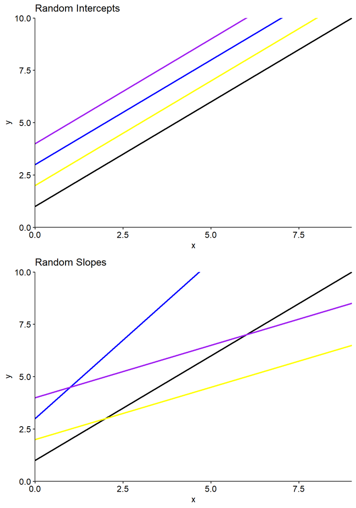

```r
ggarrange(
ggplot(expand.grid(x = c(0, 10), y = c(0, 10)), aes(x, y)) +
  geom_point(colour = "white") +
  geom_abline(intercept = 1, slope = 1, colour = "black", size = 1) +
  geom_abline(intercept = 2, slope = 1, colour = "yellow", size = 1) +
  geom_abline(intercept = 3, slope = 1, colour = "blue", size = 1) +
  geom_abline(intercept = 4, slope = 1, colour = "purple", size = 1) +
  theme_pubr() +
  coord_cartesian(xlim = c(0, 9), ylim = c(0, 10), expand=FALSE) +
  ggtitle("Random Intercepts"),
ggplot(expand.grid(x = c(0, 10), y = c(0, 10)), aes(x, y)) +
  geom_point(colour = "white") +
  geom_abline(intercept = 1, slope = 1, colour = "black", size = 1) +
  geom_abline(intercept = 2, slope = .5, colour = "yellow", size = 1) +
  geom_abline(intercept = 3, slope = 1.5, colour = "blue", size = 1) +
  geom_abline(intercept = 4, slope = .5, colour = "purple", size = 1) +
  theme_pubr() +
  coord_cartesian(xlim = c(0, 9), ylim = c(0, 10), expand=FALSE) +
ggtitle("Random Slopes"),
ncol = 1, nrow = 2)
```

To evaluate the distributional assumptions of LMMs with multiple random effects, the ideal test is to evaluate whether the random effects come from a MVN. Visualizing MVN distributions is not easy, especially with more than 2 dimensions, so instead we use another approach.

The Mahalanobis distance measures the distance between a point and a space defined by a vector of means and a covariance matrix. The “point” can be unidimensional or multidimensional and if multidimensional is not limited to only two dimensions. That is, the Mahalanobis distance can compute the distance between a multidimensional point and a multidimensional distribution. This is very convenient as it scales arbitrarily to however complex (many random effects) or simple (one random effect) we may have. If for each row of data, we calculate its Mahalanobis distance, those squared distances will follow a $\chi^{2}$ (chi-squared) distribution with degrees of freedom equal to the number of dimensions ($p$), that is a $\chi^2$ distribution with $df = p$ if the raw data were MVN. This allows us to compare our observed Mahalanobis distances to a chi-squared distribution and if they are a close match, it indicates the data on which the Mahalanobis distances were calculated were MVN. Thus, we can use Mahalanobis distances to evaluate whether a set of variables have a MVN distribution. They also can help identify multivariate outliers. We will see examples of this when we look at diagnostics for LMMs with multiple random effects.

## 1.2 Random Slopes in `R`

```r
## get rid of the haven_labeled class type for stress
dm[, dStress := as.numeric(dStress)]

m0 <- lmer(dStress ~ dEnergy + (1 | ID),
           data = dm)

summary(m0)
```

```
## Linear mixed model fit by REML. t-tests use Satterthwaite's method [
## lmerModLmerTest]
## Formula: dStress ~ dEnergy + (1 | ID)
##    Data: dm
##
## REML criterion at convergence: 942.8
##
## Scaled residuals:
##    Min     1Q Median     3Q    Max
## -3.140 -0.683  0.032  0.690  2.200
##
## Random effects:
##  Groups   Name        Variance Std.Dev.
##  ID       (Intercept) 0.712    0.844
##  Residual             1.175    1.084
## Number of obs: 283, groups:  ID, 88
##
## Fixed effects:
##             Estimate Std. Error       df t value Pr(>|t|)
## (Intercept)   4.7499     0.2574 268.8509   18.45   <2e-16 ***
## dEnergy      -0.1611     0.0573 276.1791   -2.81   0.0053 **
## ---
## Signif. codes:  0 '***' 0.001 '**' 0.01 '*' 0.05 '.' 0.1 ' ' 1
##
## Correlation of Fixed Effects:
##         (Intr)
## dEnergy -0.895
```

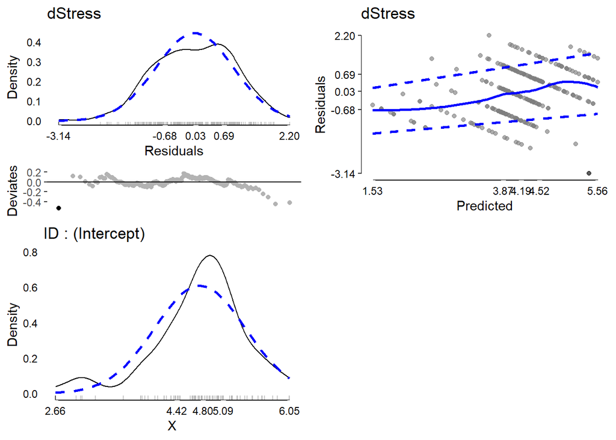

```r
plot(modelDiagnostics(m0), ncol = 2, nrow = 2, ask = FALSE)
```

From the results, we can see that on average, higher energy is associated with lower stress. Energy has not been separated into a between or within component, so we cannot say whether its driven by people who have higher energy on average having lower stress or days with higher than usual energy having lower than usual stress, or both. We can see that the residuals (top left graph panel) and random intercept by ID (bottom left graph panel) are about normally distributed with only modest if any outliers and we can see that the homogeneity of variance assumption is approximately met at least in the residuals vs fitted/predicted values (top right).

Next, we add dEnergy as a random slope by adding it inside the parentheses before ID, `(dEnergy | ID)`.

```r
m1 <- lmer(dStress ~ dEnergy + (dEnergy | ID),
           data = dm)

summary(m1)
```

```
## Linear mixed model fit by REML. t-tests use Satterthwaite's method [
## lmerModLmerTest]
## Formula: dStress ~ dEnergy + (dEnergy | ID)
##    Data: dm
##
## REML criterion at convergence: 939.4
##
## Scaled residuals:
##    Min     1Q Median     3Q    Max
## -3.191 -0.639  0.030  0.643  2.271
##
## Random effects:
##  Groups   Name        Variance Std.Dev. Corr
##  ID       (Intercept) 1.6398   1.281
##           dEnergy     0.0726   0.269    -0.80
##  Residual             1.1043   1.051
## Number of obs: 283, groups:  ID, 88
##
## Fixed effects:
##             Estimate Std. Error      df t value Pr(>|t|)
## (Intercept)   4.7054     0.2871 40.8171   16.39   <2e-16 ***
## dEnergy      -0.1476     0.0666 47.7804   -2.22    0.032 *
## ---
## Signif. codes:  0 '***' 0.001 '**' 0.01 '*' 0.05 '.' 0.1 ' ' 1
##
## Correlation of Fixed Effects:
##         (Intr)
## dEnergy -0.923
```

The output is fairly familiar to the fixed effect slope and random intercept only model but there is another random effect under the groups ID for `dEnergy`. We get the variance and standard deviation of `dEnergy` as well as the correlation between the random intercept and the random slope. The correlation is -0.7952 indicating that people who have a higher level of stress when energy is 0 (the intercept) also tend to have a more negative slope of stress on energy. Note that although the fixed effect slope estimate for energy is about the same between the two models, the standard error is larger so the p-value is higher (further away from 0) for the model with a fixed and random slope of `dEnergy` than the model with only a fixed slope of `dEnergy`. This is a fairly common pattern.

Now we can look at model diagnostic plots. We use 2 columns and 3 rows as there are more plots now, but otherwise we use the usual `modelDiagnostics()` function.

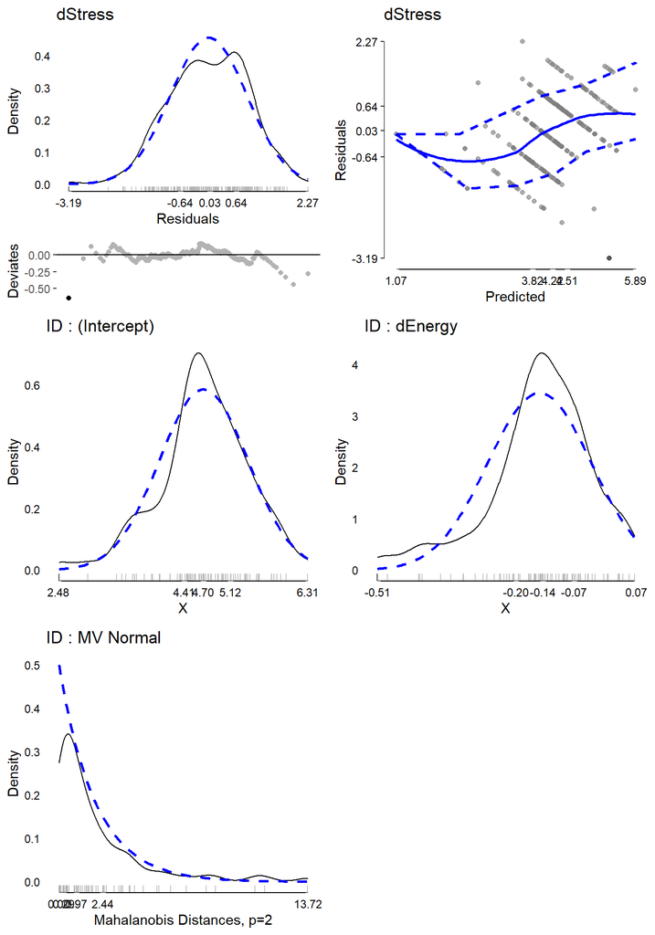

```r
plot(modelDiagnostics(m1), ncol = 2, nrow = 3, ask = FALSE)
```

In the figure, we see our familiar density and QQ deviates plot for the residuals (top left). Univariate density plots (black lines) and univariate normal distributions (blue dashed lines) for the random intercept alone (`ID : (Intercept)`) and the random slope of energy alone (`ID : dEnergy`). The naming convention is to include the coefficient name, intercept or energy for the energy slope, prefixed by what the variable name is for the random effect, here ID. Both of the univariate random effect distribution plots can be interpreted as usual and are shown on the middle row, left and right panels. What is technically graphed are the BLUPs and at the bottom we can get a five number summary to help see the minimum, 25th percentile, 50th percentile (median), 75th percentile, and maximum, which can give us some sense of the spread of the random intercept and slope. For example, for the random slope of energy, the maximum BLUP is 0.07, indicating that the highest predicted individual slope for anyone is 0.07. This tells us that not many people are expected to have *higher* stress if they have higher energy. We can also see that 50% of people have BLUPs between -0.20 and -0.07, giving us a sense of the spread of the random slopes.

The new graph is on the bottom row, left side and it evaluates whether the random effects by ID follow a MVN or not by using the Mahalanobis distances. The observed density is the black line. The theoretical density again is in dashed blue line. Here the theoretical density **is not** a normal density, but a chi-squared density with $df = p = 2$. In this case, we can see that its not a terrible fit between the observed and theoretical chi-squared density, suggesting the MVN assumption is reasonably well met. We also can see, however, that there are some relatively extreme distances, with the maximum at 13.72 being quite a bit higher than the next nearest. Although its not flagged as an extreme value, partly because there are only about 88 people.

In practice, I may not actually make any changes here. For the sake of illustration, however, and to show how to do it, we will use a more stringent criteria for extreme values. Rather than defining an extreme value as the top and bottom 0.5% of the theoretical distribution, let’s use the top and bottom 1% of the theoretical distribution. Because I know this will yield some extreme values to remove, I am saving the results of `modelDiagnostics()` in an object, `m1.diag` which I can plot but I can also use to identify which rows / IDs in the dataset are extreme and should / could be dropped. The new figure shows a few extreme values in the random effect BLUPs. Maybe a low value on the intercept, definitely a couple too low slopes, and maybe one MVN extreme value, the 13.72 Mahalanobis distance.

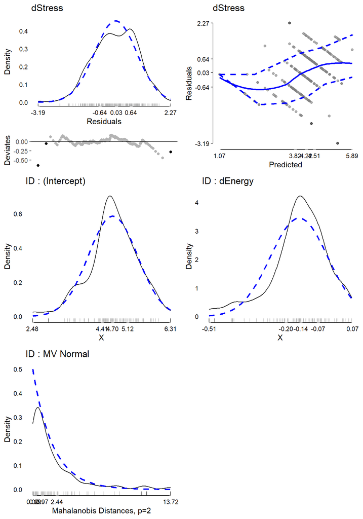

```r
m1.diag <- modelDiagnostics(m1, ev.perc = .01)
plot(m1.diag, ncol = 2, nrow = 3, ask=FALSE)
```

To consider removing these cases, we need to identify them. The `m1.diag` object in `R` has several subparts, but we are particularly interested here in the `extremeValues` subpart, which is itself a little data table, shown in the following.

```r
m1.diag$extremeValues
```

```
##     dStress  ID Index                     EffectType
##  1:       2  29    43                      Residuals
##  2:       6  64   105                      Residuals
##  3:       2 110   199                      Residuals
##  4:       6  23    29 Random Effect ID : (Intercept)
##  5:       6  23    30 Random Effect ID : (Intercept)
##  6:       7  23    31 Random Effect ID : (Intercept)
##  7:       6  23    32 Random Effect ID : (Intercept)
##  8:       3  23    33 Random Effect ID : (Intercept)
##  9:       2 109   195 Random Effect ID : (Intercept)
## 10:       2 109   196 Random Effect ID : (Intercept)
## 11:       2 109   197 Random Effect ID : (Intercept)
## 12:       1 109   198 Random Effect ID : (Intercept)
## 13:       1 143   250 Random Effect ID : (Intercept)
## 14:       1 143   251 Random Effect ID : (Intercept)
```

[output cut: 26 more lines]

In this extreme values data table, we can see a few columns. The most important columns are:

- `ID` this is the ID variable from the dataset and will be helpful later.
- `Index` this is the row number in the dataset used in the LMM and can be used to identify specific rows of data that are extreme.
- `EffectType` this indicates what type of effect the extreme value was identified on.

The first column, `dstress` just shows the outcome variable score for reference, which may help but is not necessarily that useful always. The name of the first column will depend on the name of the outcome variable

In this dataset, we can see that there are three extreme values identified on the residuals. For all the random effects, because the BLUPs are calculated per person, not per observation if a person is classified as an extreme value, then all observations belonging to that specific ID will be shown. That is because at the random effect level, a person as a whole unit is either extreme or not and if extreme the only “choice” would be to exclude / modify that entire person.

Because there are multiple types of extreme values, we could have some choice in how to address them. We could remove any extreme values, or remove one at a time and re-run the model to see if anything else remained extreme or not. For example, we can see that ID 23 is an extreme value on the random effect of dEnergy as well as the random intercept. Dropping ID 23 might change the rest enough that say some of the other residuals are no longer extreme. Conversely, we could drop some of the extreme residuals, specific ‘weird’ days and see if that happens to address any of the random effects. In this case, it is not too likely as the extreme residuals come from different participants (IDs 29, 64, 110) than do the extreme values on the random effects.

A relatively intense approach would be to drop all of these extreme values and re-estimate the LMM in the dataset with these rows / IDs excluded. Here are different ways that we could do that.

The first approach uses the `Index` column from the extreme values data table and then we pass that to our dataset, `dm` and use the minus sign to indicate we want to drop those rows of data. Note that because the same rows are extreme on a few different measures, we use the `unique()` function so that we only drop each row once. This never hurts to use, as if all rows are already unique its fine, but it helps if there are duplicate extreme values (e.g., Index 29 is extreme on the random intercept and random effect of dEnergy).

```r
dm.noev1 <- dm[-unique(m1.diag$extremeValues$Index)]
```

Another approach, supposing we only wanted to drop selected IDs. For example, we could decide that we want to only get rid of ID 23. Here we use the `%nin%` operator which takes a variable on the left and returns `TRUE` if it is not in (nin) the value/vector of values on the right hand side. This operator comes from the `extraoperators` package so we need to have that loaded.

```r
dm.noev2 <- dm[ID %nin% 23]

#Here I'm going to create an alternate version of this with a different ID (29) to show you something later, forget it for now:
dm.noev2a <- dm[ID %nin% 29]
```

Supposing we wanted to remove IDs 23, 109 and 143, we could use the same approach but instead of listing one ID, we’d list all three as a vector, like this:

```r
dm.noev3 <- dm[ID %nin% c(23, 109, 143)]
```

If we wanted to only exclude one type of effect, say only the MVN extreme values, we could use the row indices but pre-select specific effect types. We can do this because the extreme values dataset is a regular data table, so we can operate on it the same as we would on any dataset. Let’s just confirm that we can subset the extreme values dataset to only give us the MVN extreme values.

```r
m1.diag$extremeValues[EffectType == "Multivariate Random Effect ID"]
```

```
##     dStress  ID Index                    EffectType
##  1:       1 143   250 Multivariate Random Effect ID
##  2:       1 143   251 Multivariate Random Effect ID
##  3:       1 145   257 Multivariate Random Effect ID
##  4:       1 145   258 Multivariate Random Effect ID
##  5:       1 145   259 Multivariate Random Effect ID
##  6:       1 145   260 Multivariate Random Effect ID
##  7:       1 145   261 Multivariate Random Effect ID
##  8:       1 150   270 Multivariate Random Effect ID
##  9:       2 150   271 Multivariate Random Effect ID
## 10:       1 150   272 Multivariate Random Effect ID
## 11:       1 150   273 Multivariate Random Effect ID
```

Now that that works, we can use the same approach we did to exclude all extreme values, but using this subsetted dataset. We replace: `m1.diag$extremeValues` with `m1.diag$extremeValues[EffectType == "Multivariate Random Effect ID"]` and then we use just the `Index` column as before by writing: `$Index`.

```r
dm.noev4 <- dm[-unique(m1.diag$extremeValues[EffectType == "Multivariate Random Effect ID"]$Index)]
```

If you wanted even more customized options, you could achieve those by making the subsetting of the extreme values dataset fancier (e.g., picking multiple but not all effect types, etc.).

This is one of the benefits of `R` and an approach where everything is an object. We can use the output from one function, `modelDiagnostics()`, and because it returns an object, a dataset of extreme values, we can operate on it as we want and then use those results to subset our main dataset for analysis.

At this point, we can re-run our analysis using the revised dataset. For the sake of example, I will just use our dataset that excluded only one person, `dm.noev2`.

```r
m1noev <- lmer(dStress ~ dEnergy + (dEnergy | ID),
           data = dm.noev2)

summary(m1noev)
```

```
## Linear mixed model fit by REML. t-tests use Satterthwaite's method [
## lmerModLmerTest]
## Formula: dStress ~ dEnergy + (dEnergy | ID)
##    Data: dm.noev2
##
## REML criterion at convergence: 920
##
## Scaled residuals:
##    Min     1Q Median     3Q    Max
## -3.212 -0.646  0.017  0.646  2.277
##
## Random effects:
##  Groups   Name        Variance Std.Dev. Corr
##  ID       (Intercept) 1.3082   1.144
##           dEnergy     0.0573   0.239    -0.73
##  Residual             1.0991   1.048
## Number of obs: 278, groups:  ID, 87
##
## Fixed effects:
##             Estimate Std. Error      df t value Pr(>|t|)
## (Intercept)   4.6250     0.2799 37.0637   16.52   <2e-16 ***
## dEnergy      -0.1308     0.0651 44.9924   -2.01     0.05 .
## ---
## Signif. codes:  0 '***' 0.001 '**' 0.01 '*' 0.05 '.' 0.1 ' ' 1
##
## Correlation of Fixed Effects:
##         (Intr)
## dEnergy -0.917
```

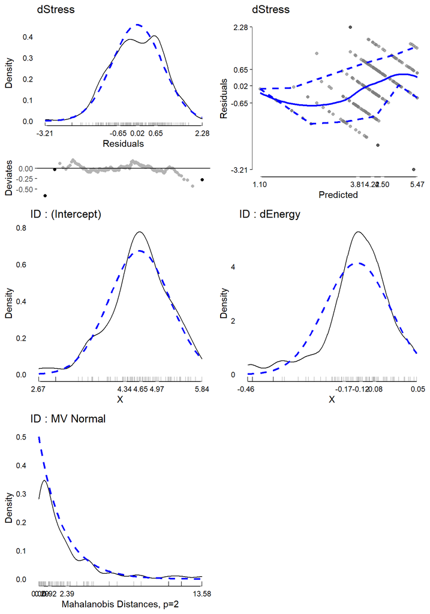

```r
m1noev.diag <- modelDiagnostics(m1noev, ev.perc = .01)
plot(m1noev.diag, ncol = 2, nrow = 3, ask=FALSE)
```

The results look fairly similar, although the correlation between the random intercept and slope has dropped from -0.7952 to -0.7307 and the average slope of energy on stress, the fixed effect part, is somewhat weaker going from -0.1476 to -0.1308.

The diagnostics also look improved.

A shorter trick to re-running the same model on a new dataset is to use the `update()` function. The `update()` function takes an existing model, and you can update that model in different ways. Here, we will update the model by just using a new dataset, here the dataset where we only excluded a different ID, `dm.noev2a`. This is just to illustrate how easy it is even without knowing the formula for a model to just update an old model on a different dataset. This is very helpful for running models with and without extreme values or with and without some participants who perhaps did not follow the study protocol correctly, etc. The benefit of using `update()` is that even if you have lots of predictors in your model, you don’t have to type them all again and you are guaranteed to have the same model as before, just with a new dataset, no chance for typos and forgetting a predictor or covariate.

```r
m1noev2 <- update(m1, data = dm.noev2a)
summary(m1noev2)
```

```
## Linear mixed model fit by REML. t-tests use Satterthwaite's method [
## lmerModLmerTest]
## Formula: dStress ~ dEnergy + (dEnergy | ID)
##    Data: dm.noev2a
##
## REML criterion at convergence: 906.5
##
## Scaled residuals:
##     Min      1Q  Median      3Q     Max
## -2.4072 -0.5952  0.0296  0.6561  2.4018
##
## Random effects:
##  Groups   Name        Variance Std.Dev. Corr
##  ID       (Intercept) 2.0625   1.436
##           dEnergy     0.0883   0.297    -0.85
##  Residual             1.0119   1.006
## Number of obs: 278, groups:  ID, 87
##
## Fixed effects:
##             Estimate Std. Error      df t value Pr(>|t|)
## (Intercept)   4.7066     0.2956 39.3327   15.92   <2e-16 ***
## dEnergy      -0.1544     0.0677 45.6797   -2.28    0.027 *
## ---
## Signif. codes:  0 '***' 0.001 '**' 0.01 '*' 0.05 '.' 0.1 ' ' 1
##
## Correlation of Fixed Effects:
##         (Intr)
## dEnergy -0.929
```

```r
# Note - you could do this theoretically with any of the dm.noev models we created.
# It just so happens that when we remove too much in our dataset, the models don't coverge!
```

In the previous topic, we added both between and within person variants of a predictor into a LMM as fixed effects. Now let’s take a look at doing that with both fixed and random slopes. First, we need to create a between and within person version of our predictor, `dEnergy`. Note that this only works because energy was measured each day (which is why it has the d at the front of the variable name). It would not work if `dEnergy` was measured only once, it would already be a between person variable. Note also that mean deviations only makes sense for continuous predictors. If `dEnergy` was binary, it would not make sense to look at the average and the deviations from the average, probably.

```r
dm[, c("Benergy", "Wenergy") := meanDeviations(dEnergy), by = ID]
```

Now we can fit a LMM with `Benergy` and `Wenergy` as fixed effects and a random intercept and random slope for `Wenergy`. Note that the random intercept is included automatically, without us having to ask for it explicitly. We also look at the model diagnostics and confidence intervals.

```r
iccMixed("dStress",id="ID",data=dm) ## Let's get the ICC
```

```
##         Var  Sigma    ICC
## 1:       ID 0.7845 0.3989
## 2: Residual 1.1823 0.6011
```

```r
m2 <- lmer(dStress ~ Benergy + Wenergy +
             (Wenergy | ID),
           data = dm)

summary(m2)
```

```
## Linear mixed model fit by REML. t-tests use Satterthwaite's method [
## lmerModLmerTest]
## Formula: dStress ~ Benergy + Wenergy + (Wenergy | ID)
##    Data: dm
##
## REML criterion at convergence: 942.5
##
## Scaled residuals:
##    Min     1Q Median     3Q    Max
## -3.198 -0.633  0.032  0.659  2.239
##
## Random effects:
##  Groups   Name        Variance Std.Dev. Corr
##  ID       (Intercept) 0.713    0.844
##           Wenergy     0.050    0.224    -0.15
##  Residual             1.116    1.056
## Number of obs: 283, groups:  ID, 88
##
## Fixed effects:
##             Estimate Std. Error      df t value Pr(>|t|)
## (Intercept)   5.2794     0.4838 82.9319   10.91   <2e-16 ***
## Benergy      -0.2931     0.1169 83.9335   -2.51    0.014 *
## Wenergy      -0.1186     0.0733 23.1610   -1.62    0.119
## ---
## Signif. codes:  0 '***' 0.001 '**' 0.01 '*' 0.05 '.' 0.1 ' ' 1
##
## Correlation of Fixed Effects:
##         (Intr) Benrgy
## Benergy -0.972
## Wenergy -0.015  0.005
```

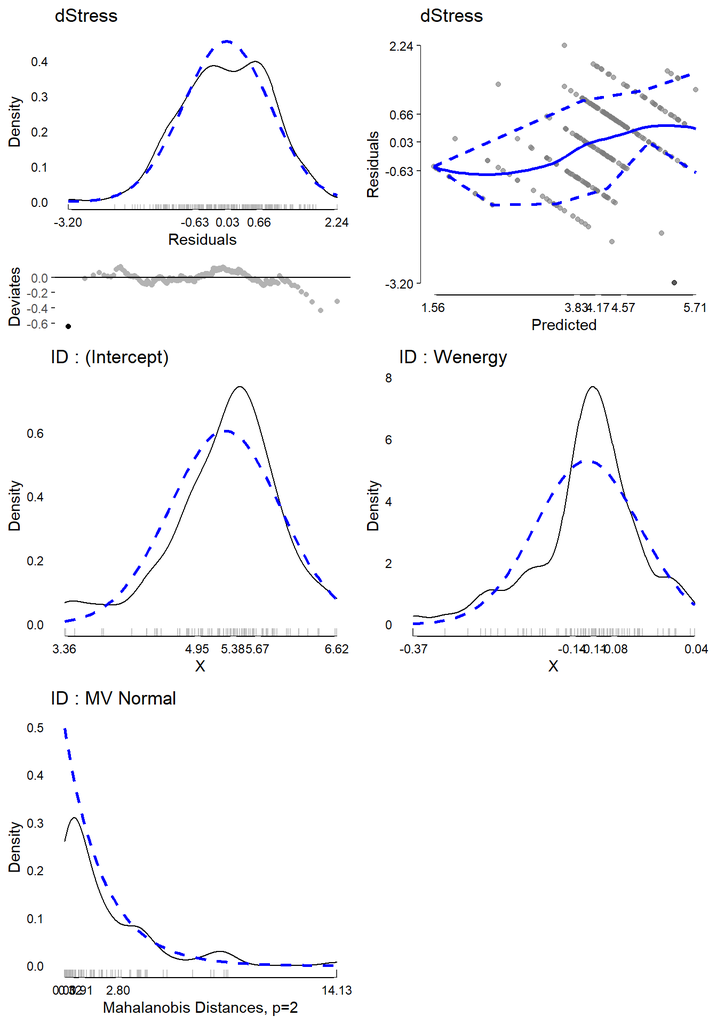

```r
m2.diag <- modelDiagnostics(m2)
plot(m2.diag, ncol = 2, nrow = 3, ask=FALSE)
```

```r
m2.ci <- confint(m2, oldNames = FALSE)
```

```
## Computing profile confidence intervals ...
```

[output not shown]

[output cut: 223 more lines]

[output not shown]

```r
m2.ci
```

```
##                              2.5 %   97.5 %
## sd_(Intercept)|ID           0.6365  1.04626
## cor_Wenergy.(Intercept)|ID -1.0000  1.00000
## sd_Wenergy|ID               0.0000  0.47787
## sigma                       0.9424  1.19058
## (Intercept)                 4.3240  6.22764
## Benergy                    -0.5222 -0.06235
## Wenergy                    -0.2643  0.02849
```

A conceptual example of why the between and within might differ. Imagine that you look at the relationship between exercise and well being. You might find that people that exercise more on average have better average wellbeing. However, if people exercise more than usual for them, they might over exercise and that be associated with worse wellbeing. Because overexercising is relative to an individuals’ own fitness level, it only shows up at the within person only level. Although this is relatively rare, it often happens that the magnitude of effects varies across the between person and within person effects.

Visually, all the diagnostics look relatively OK, although there are a few extreme values (now using the default top and bottom 0.5% of the theoretical distribution definition) on the residuals and on the random intercept. In practice, it would be worthwhile to consider whether these extreme values should be addressed somehow or if you are comfortable proceeding as is.

The profile likelihood confidence intervals take a few seconds to complete and generate a few warnings related to the fact that the lower bound for the intercept-slope correlation is -1, the lowest possible correlation.

### 1.2.1 Sample Write Up

A linear mixed model was fit to 283 stress scores from 88 people. The intraclass correlation coefficient of stress, the outcome, was 0.3989 and of energy, the predictor was 0.2753, indicating that about 40% of the total variance in stress and about 28% of the total variance in energy exists between people with the remaining due to daily fluctuations within people. The fixed effect intercept revealed that the estimated average [95% CI] stress was 5.2794 [4.32, 6.23], when `Benergy` and `Wenergy` are zero. However, there were individual differences, with the standard deviation for the random intercept being 0.8442 indicating that there are individual differences. Assuming the random intercepts follow a normal distribution, we expect most people to fall within one standard deviation of the mean, which in these data would be somewhere between: 4.4352, 6.1235. There was also a significant fixed effect of average energy on stress, such that each one unit higher average energy people had was associated with -0.2931 95% CI = [-0.52, -0.06] lower stress.

There was no significant fixed effect of within person energy on stress,-0.1186 95% CI = [-0.26, 0.03].

(If this would have been significant, you could report that: On days where people were one unit higher on energy than their own average, people were expected to have -0.1186 95% CI = [-0.26, 0.03] lower stress that same day, on average. However, there were individual differences, with the standard deviation for the random slope being 0.2236 indicating that there are individual differences in the slope of within person energy on stress. Assuming the random slope follow a normal distribution, we expect most people to fall within one standard deviation of the mean, which in these data would indicate that most people are expected to have a within person slope of stress on energy between: -0.3422, 0.105.)

Finally, there was a negative correlation between the random intercept and slope, -0.1503 indicating that compared to the population averages, people who had a relatively higher stress when energy was 0 also tended to have a more negative within person association between energy and stress.

## 1.3 Solving Convergence/Estimation Issues

We have talked before some about convergence, where algorithms iterate through cycles and try to find the best parameter estimates. Sometimes this process fails or runs into problems, which we may broadly call convergence or estimation issues.

Sometimes these do not make too big of a difference, sort of false positives, but sometimes these issues may severely impact a models’ results. If you see warnings about convergence or estimation, its best to address and resolve them before being confident in the model results.

Let’s create a between and within version of the daily variable, `dMood` and look at a fixed and random slope LMM predicting stress from mood

```r
dm[, c("Bmood", "Wmood") := meanDeviations(dMood), by = ID]

# Please note, for demonstration purposes, I'm using a different outcome variable, "stress"
# rather than dStress (as that model converged fine) - stress is just the average across days
mest <- lmer(stress ~ Bmood + Wmood +
             (Wmood | ID),
             data = dm)
```

```
## boundary (singular) fit: see ?isSingular
```

```
## Warning: Model failed to converge with 1 negative eigenvalue: -1.3e-05
```

When we estimate the model, we get a message about a boundary (singular) fit with the suggestion to see `?isSingular`. This is a helpful suggestion and provides more details on potential approaches to resolving it. If we run `?isSingular` in the `R` console will get a help page with some more information, which you **should** do and go read now.

Armed with that knowledge, we can run a `summary()` on our model to learn a bit more. Its not always clear, but in this case we can see a correlation of 1 between the random intercept and slope that is causing the singularity.

```r
summary(mest)
```

```
## Linear mixed model fit by REML. t-tests use Satterthwaite's method [
## lmerModLmerTest]
## Formula: stress ~ Bmood + Wmood + (Wmood | ID)
##    Data: dm
##
## REML criterion at convergence: -3541
##
## Scaled residuals:
##       Min        1Q    Median        3Q       Max
## -3.65e-04 -2.11e-05 -2.70e-06  2.07e-05  2.20e-04
##
## Random effects:
##  Groups   Name        Variance Std.Dev. Corr
##  ID       (Intercept) 1.20e-01 3.46e-01
##           Wmood       1.83e-19 4.28e-10 1.00
##  Residual             2.98e-10 1.73e-05
## Number of obs: 283, groups:  ID, 88
##
## Fixed effects:
##              Estimate Std. Error        df t value Pr(>|t|)
## (Intercept)  3.99e+00   1.92e-01  3.36e+02   20.85  < 2e-16 ***
## Bmood       -2.95e-01   3.90e-02  4.46e+02   -7.56  2.4e-13 ***
## Wmood        1.40e-10   1.22e-06  2.03e+03    0.00        1
## ---
## Signif. codes:  0 '***' 0.001 '**' 0.01 '*' 0.05 '.' 0.1 ' ' 1
##
## Correlation of Fixed Effects:
##       (Intr) Bmood
## Bmood -0.981
## Wmood  0.000  0.000
## convergence code: 0
## boundary (singular) fit: see ?isSingular
```

Our options for resolving this are listed in `?isSingular`. In this case, a simple path forward is to remove some random effects. We basically always keep a random intercept in our LMMs, so the only candidate to remove is the random slope for `Wmood`. Sometimes when doing that we no longer get the singularity warning, but in this case, the model still failed to converge, so we should not trust the results.

```r
mest2 <- lmer(stress ~ Bmood + Wmood +
             (1 | ID),
             data = dm)
```

```
## Warning in checkConv(attr(opt, "derivs"), opt$par, ctrl = control$checkConv, :
## Model failed to converge with max|grad| = 0.0412584 (tol = 0.002, component 1)
```

```
## Warning in checkConv(attr(opt, "derivs"), opt$par, ctrl = control$checkConv, : Model is nearly unidentifiable: very large eigenvalue
##  - Rescale variables?
```

```r
summary(mest2)
```

```
## Linear mixed model fit by REML. t-tests use Satterthwaite's method [
## lmerModLmerTest]
## Formula: stress ~ Bmood + Wmood + (1 | ID)
##    Data: dm
##
## REML criterion at convergence: -5218
##
## Scaled residuals:
##       Min        1Q    Median        3Q       Max
## -1.67e-06 -2.02e-07 -3.69e-08  2.31e-07  2.22e-06
##
## Random effects:
##  Groups   Name        Variance Std.Dev.
##  ID       (Intercept) 1.20e-01 3.46e-01
##  Residual             5.24e-14 2.29e-07
## Number of obs: 283, groups:  ID, 88
##
## Fixed effects:
##              Estimate Std. Error        df t value Pr(>|t|)
## (Intercept)  4.00e+00   1.82e-01  4.45e-02   21.98     0.79
## Bmood       -2.92e-01   3.71e-02  4.27e-02   -7.87     0.83
## Wmood        1.57e-17   1.61e-08  4.28e-01    0.00     1.00
##
## Correlation of Fixed Effects:
##       (Intr) Bmood
## Bmood -0.979
## Wmood  0.000  0.000
## convergence code: 0
## Model failed to converge with max|grad| = 0.0412584 (tol = 0.002, component 1)
## Model is nearly unidentifiable: very large eigenvalue
##  - Rescale variables?
```

If you have multiple random slopes, it can be tricky to decide which one to drop.

Now let’s look at a convergence issue. For this, we’ll use another dataset, the `aces_daily` data. First we setup the data (from the `JWileymisc` package) and then fit a model with a random slope of stress predicting negative affect.

```r
data(aces_daily)

mconv <- lmer(NegAff ~ STRESS + (1 + STRESS | UserID),
          data = aces_daily)
```

```
## Warning in checkConv(attr(opt, "derivs"), opt$par, ctrl = control$checkConv, :
## Model failed to converge with max|grad| = 0.00201381 (tol = 0.002, component 1)
```

In this case, we get a warning message that the model did not converge. This is not a singularity issue. This means that the algorithm that tries to find the best parameter estimates tried and failed to find estimates its confident are ‘best’. For now, we won’t worry too much about what the ‘best’ actually means. In this case, sometimes using a different optimizer, basically the algorithm that goes about trying to find the best estimates, or changing its options can help. We can control the underlying algorithms using the `lmerControl()` function. In this unit, we are not going to talk much about the different options but just show one alternate you could try if you run into convergence problems.

```r
## use the control function to pick a  different algorithm
## and adjust the options to be a bit stricter
## may take longer but also may have a better chance of converging
strictControl <- lmerControl(optCtrl = list(
   algorithm = "NLOPT_LN_NELDERMEAD",
   xtol_abs = 1e-12,
   ftol_abs = 1e-12))

## now fit our model
mconv2 <- lmer(NegAff ~ STRESS + (1 + STRESS | UserID),
               data = aces_daily,
               control = strictControl)
```

In this case, the change in algorithm and options did it and we now get our model converging without warnings. Sometimes it may still have warnings and none of what you know how to try will solve those. In those cases, you’d either want to consult an expert or simplify the model. Very often, much as with singularity issues, convergence issues surround the random effects in a model. If you remove some of the random effects (at the extreme a random intercept only) you are likely to resolve the convergence issues, although you may give up aspects of the model you wanted to keep.

Sometimes as well, the convergence issues may not make much difference. Here we can look at the model results that did not converge quite and those that did.

```r
summary(mconv)
```

```
## Linear mixed model fit by REML. t-tests use Satterthwaite's method [
## lmerModLmerTest]
## Formula: NegAff ~ STRESS + (1 + STRESS | UserID)
##    Data: aces_daily
##
## REML criterion at convergence: 7706
##
## Scaled residuals:
##    Min     1Q Median     3Q    Max
## -4.994 -0.505 -0.145  0.403  6.225
##
## Random effects:
##  Groups   Name        Variance Std.Dev. Corr
##  UserID   (Intercept) 0.04238  0.2059
##           STRESS      0.00458  0.0677   0.47
##  Residual             0.17464  0.4179
## Number of obs: 6389, groups:  UserID, 191
##
## Fixed effects:
##             Estimate Std. Error       df t value Pr(>|t|)
## (Intercept) 1.24e+00   1.70e-02 1.60e+02    72.8   <2e-16 ***
## STRESS      1.18e-01   5.77e-03 1.84e+02    20.5   <2e-16 ***
## ---
## Signif. codes:  0 '***' 0.001 '**' 0.01 '*' 0.05 '.' 0.1 ' ' 1
##
## Correlation of Fixed Effects:
##        (Intr)
## STRESS 0.182
## convergence code: 0
## Model failed to converge with max|grad| = 0.00201381 (tol = 0.002, component 1)
```

```r
summary(mconv2)
```

```
## Linear mixed model fit by REML. t-tests use Satterthwaite's method [
## lmerModLmerTest]
## Formula: NegAff ~ STRESS + (1 + STRESS | UserID)
##    Data: aces_daily
## Control: strictControl
##
## REML criterion at convergence: 7706
##
## Scaled residuals:
##    Min     1Q Median     3Q    Max
## -4.994 -0.505 -0.145  0.403  6.225
##
## Random effects:
##  Groups   Name        Variance Std.Dev. Corr
##  UserID   (Intercept) 0.04237  0.2058
##           STRESS      0.00458  0.0677   0.47
##  Residual             0.17464  0.4179
## Number of obs: 6389, groups:  UserID, 191
##
## Fixed effects:
##             Estimate Std. Error       df t value Pr(>|t|)
## (Intercept) 1.24e+00   1.70e-02 1.60e+02    72.8   <2e-16 ***
## STRESS      1.18e-01   5.77e-03 1.84e+02    20.5   <2e-16 ***
## ---
## Signif. codes:  0 '***' 0.001 '**' 0.01 '*' 0.05 '.' 0.1 ' ' 1
##
## Correlation of Fixed Effects:
##        (Intr)
## STRESS 0.182
```

In this instance, the only apparent difference is in the 4th decimal point of the standard deviation of the random intercept. While the first algorithm did not quite achieve estimates it was confident are the best, it was really very close. Sometimes however, the estimates could be far off. If you cannot get a model that converges, though, you have no comparison so its hard to know if the non convergence was an issue or not. That is why its generally the best idea to always resolve a non convergence issue if possible and be very cautious about interpreting a model that did not converge.

# 2 Graphing LMMs

We can graph results from LMMs much as we do for linear regressions or GLMs. There are a few nuances, however. In LMMs, people sometimes refer to marginal or conditional effects. In some ways, these correspond to the idea of fixed or random effects.

Marginal predictions are based only on the averages, basically the fixed effects portion of the model. Conditional predictions incorporate **both** the fixed and random effects portion of the model.

Because the conditional predictions incorporate random effects, they can only be made for the existing data because it is impossible to know what a new person would look like (e.g., if you recruited one more participant, would their BLUP be like ID 1, ID 2, or ID XX?). Therefore, conditional predictions are only made off the data used to build the model. Marginal predictions could be made for new data, though to answer a question like, what would the model predict, on average, the stress score would be if mood was 2 points above average on a day? That would not tell you how any single individual is predicted to be, but does indicate what, on average, the prediction would be from the model. Additionally, because conditional predictions will vary by ID, we can get different conditional predictions for each participant in the dataset. We will look at examples of both of these briefly.

## 2.1 Marginal

Graphs based off the marginal predictions from the model are probably the default and most common approach. These graphs show the average association or predictions from the model and basically graph the fixed effects part of the model. They are interpreted nearly identically to linear regression graphs.

To start, we will use our model with between person and within person energy predicting stress with a random intercept and random slope for within person energy, called `m2`. We use the `visreg()` function to graph the results with the x axis being `Benergy` and the y axis the predicted stress scores.

```r
m2 <- lmer(dStress ~ Benergy + Wenergy +
             (Wenergy | ID),
           data = dm)

visreg(m2, xvar = "Benergy")
```

```
## Error in data.frame(x, x2, check.names = FALSE): arguments imply differing number of rows: 283, 1
```

This however results in an error message about a differing number of rows. Its not clear from the error message, but since everything else in the code is right, we can infer this error message has something to do with the underlying data. We can use the `str()` function to get the classes in `R` for each of our variables.

```r
str(dm[, .(dStress, Benergy, Wenergy, ID)])
```

```
## Classes 'data.table' and 'data.frame':   283 obs. of  4 variables:
##  $ dStress: num  4 3 2 6 5 5 5 6 6 6 ...
##  $ Benergy: num  3.67 3.67 3.67 6 6 ...
##  $ Wenergy: 'haven_labelled' num  2.333 -2.667 0.333 0 0 ...
##   ..- attr(*, "label")= chr "How would you rate your energy level today?"
##   ..- attr(*, "format.spss")= chr "F40.0"
##   ..- attr(*, "display_width")= int 5
##   ..- attr(*, "labels")= Named num  1 2 3 4 5 6 7
##   .. ..- attr(*, "names")= chr  "Very low" "Low" "Somewhat low" "Neither low nor high" ...
##  $ ID     : num  10 10 10 12 12 13 13 13 13 13 ...
##   ..- attr(*, "format.spss")= chr "F20.0"
##   ..- attr(*, "display_width")= int 13
##  - attr(*, ".internal.selfref")=<externalptr>
```

Here we can see that `Wenergy` has the class haven labeled. As this is not a common class (common classes in `R` are logical, integer, factor, numeric, character), its a reasonable guess that is causing the trouble. `visreg()` may not know how to work with haven labeled type variables. We don’t need the labels so we can convert `Wenergy` to a numeric variable and try again. Since we are using a model, after updating `Wenergy` we need to re-run our LMM. The results will not change but hopefully now `visreg()` will work as expected.

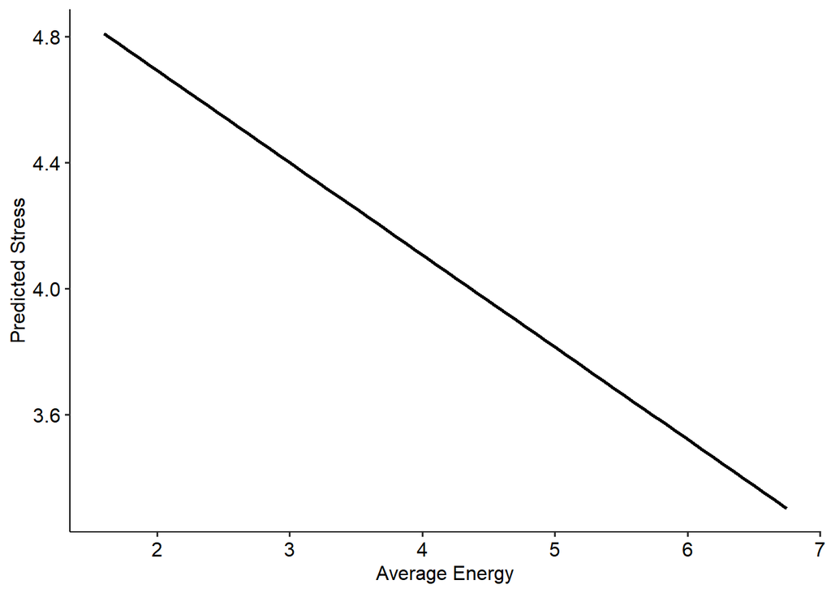

```r
dm[, Wenergy := as.numeric(Wenergy)]

m2 <- lmer(dStress ~ Benergy + Wenergy +
             (Wenergy | ID),
           data = dm)

visreg(m2, xvar = "Benergy",
       partial = FALSE, rug = FALSE,
       gg = TRUE,
       xlab = "Average Energy",
       ylab = "Predicted Stress",
       line = list(col = "black", size = 1)) +
  theme_pubr()
```

The graph shows us how average energy (between person energy) and stress are associated on average. We made a number of customizations to the graph, including not showing partial residuals, no rug plot, defining our own x and y axis labels, and changing the line colour to black (the default is blue), and use the `pubr` theme.

We can make the same plot for within person energy. We just change the `xvar` option to be `Wenergy`. We also make a bit fancier x axis label. Note the use of “” that tells `R` that we want a line break in the x axis label.

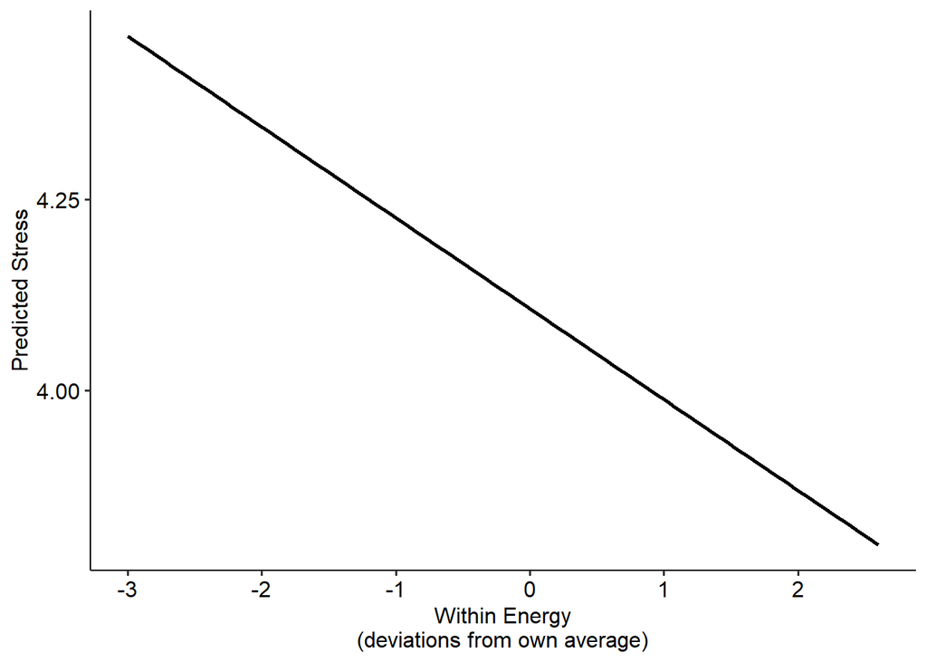

```r
visreg(m2, xvar = "Wenergy",
       partial = FALSE, rug = FALSE,
       gg = TRUE,
       xlab = "Within Energy\n(deviations from own average)",
       ylab = "Predicted Stress",
       line = list(col = "black", size = 1)) +
  theme_pubr()
```

This figure shows the negative fixed effect coefficient for `Wenergy` graphically.

## 2.2 Conditional

We can use `visreg()` function to graph conditional predictions as well. We will make a few modifications compared to the marginal graph.

1. We specify that we want lines `by = "ID"` to indicate we should get a separate line for each ID.
2. We specify particular `breaks`, these are the breaks for the `by` variable and in this case indicate which specific IDs should be plotted. To see available IDs, we look at `unique(dm$ID)`. I’ve chosen a few IDs to show for example. You could pick others.
3. We specify the `re.form` argument. If we want to incorporate all random effects in the predictions, we should specify the same formula for random effects as we did in the model. If we want to only incorporate some but not all random effects, we can specify a modified formula, we’ll look at some examples a bit later.

With those changes we get the following figure. Each ID is separated into a separate plot panel.

```r
unique(dm$ID)
```

```
##  [1]  10  12  13  14  15  16  18  20  22  23  24  25  26  27  29  31  32  33  34
## [20]  35  37  40  42  49  50  51  54  56  57  59  60  61  62  64  65  66  67  69
## [39]  70  72  73  74  75  76  77  78  80  82  83  85  86  88  90  94  95  96  97
## [58]  98  99 101 102 105 109 110 111 112 114 118 119 120 121 124 125 131 134 135
## [77] 136 137 138 141 143 144 145 146 148 150 151 155
```

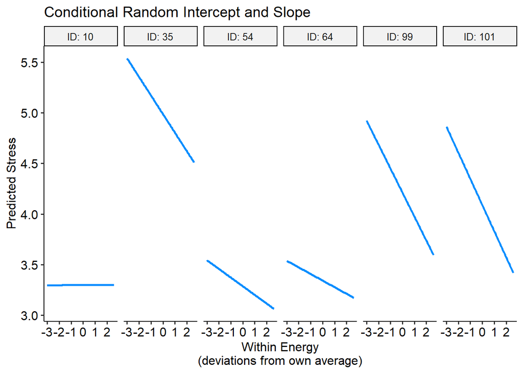

```r
visreg(m2, xvar = "Wenergy", by = "ID",
       breaks = c(10, 35, 54, 64, 99, 101),
       re.form = ~ (Wenergy | ID),
       partial = FALSE, rug = FALSE,
       gg = TRUE,
       xlab = "Within Energy\n(deviations from own average)",
       ylab = "Predicted Stress") +
  theme_pubr() +
  ggtitle("Conditional Random Intercept and Slope")
```

Note that these are not raw regression lines per person, they are conditional predictions from the LMM, so they will include shrinkage of the random intercept and slopes to the overall sample average intercept and slope. Nevertheless, we can see that there are quite large differences in the within person association between energy and stress for say ID 10 compared to ID 101. They are not the same, and although in the marginal plots section earlier, we saw that on average there is a negative association between within person energy and stress, not everyone exactly has a negative predicted slope (10 looks a little positive).

If we did not want to incorporate all random effects in the predictions, we could modify the `re.form`. This does not change the LMM we fit, it merely changes which random effects are incorporated into the predictions from the regression model and then plotted. For example, we could only include the intercept, which gives us the following figure:

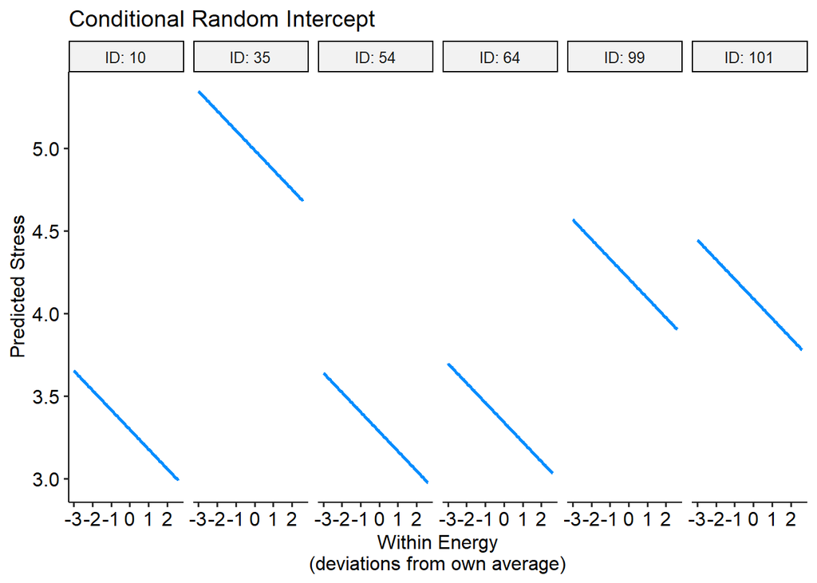

```r
visreg(m2, xvar = "Wenergy", by = "ID",
       breaks = c(10, 35, 54, 64, 99, 101),
       re.form = ~ (1 | ID),
       partial = FALSE, rug = FALSE,
       gg = TRUE,
       xlab = "Within Energy\n(deviations from own average)",
       ylab = "Predicted Stress") +
  theme_pubr() +
  ggtitle("Conditional Random Intercept")
```

Finally, if we leave out the `re.form` section all together, we get the marginal intercept and marginal slope, which is just the same as our marginal graph but repeated for each ID, a fairly useless figure, but it highlights what happens if you forget to include `re.form` in your conditional graph.

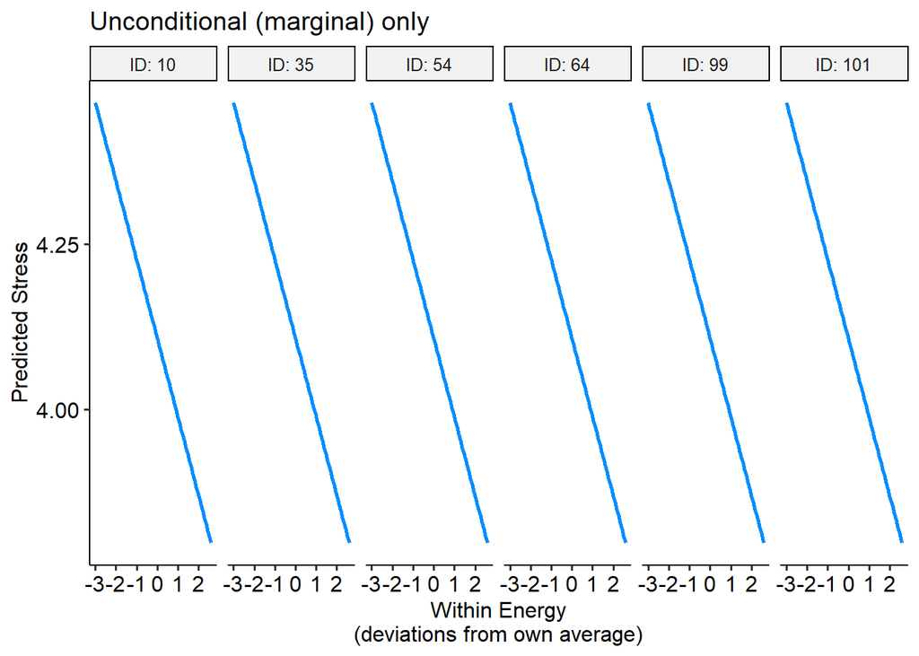

```r
visreg(m2, xvar = "Wenergy", by = "ID",
       breaks = c(10, 35, 54, 64, 99, 101),
       partial = FALSE, rug = FALSE,
       gg = TRUE,
       xlab = "Within Energy\n(deviations from own average)",
       ylab = "Predicted Stress") +
  theme_pubr() +
  ggtitle("Unconditional (marginal) only")
```

If you don’t want to look at specific IDs too carefully but instead want to get some sense of the overall variation or you have small number of IDs, you can overlay all the lines together by specifying `overlay = TRUE`.

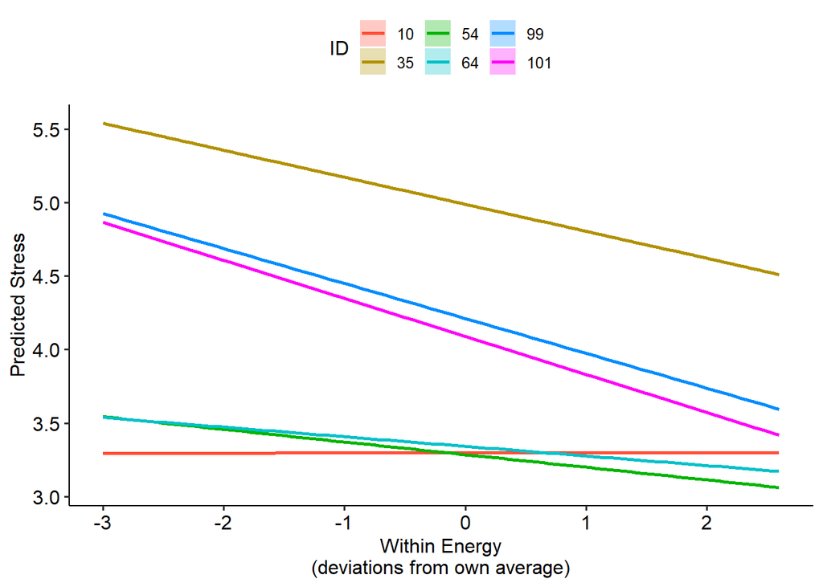

```r
visreg(m2, xvar = "Wenergy", by = "ID",
       breaks = c(10, 35, 54, 64, 99, 101),
       re.form = ~ (Wenergy | ID),
       partial = FALSE, rug = FALSE,
       gg = TRUE,
       xlab = "Within Energy\n(deviations from own average)",
       ylab = "Predicted Stress",
       overlay = TRUE) +
  theme_pubr()
```

To see the overall variation in conditional intercepts and slopes, we could set the breaks equal to all the IDs by using: `breaks = unique(dm$ID)`.

[figure not shown]

```r
visreg(m2, xvar = "Wenergy", by = "ID",
       breaks = unique(dm$ID),
       re.form = ~ (Wenergy | ID),
       partial = FALSE, rug = FALSE,
       gg = TRUE,
       xlab = "Within Energy\n(deviations from own average)",
       ylab = "Predicted Stress",
       overlay = TRUE) +
  theme_pubr()
```

With so many different people, we probably do not care about or want the legend, we can turn that off in `ggplot2` by adding no position to the legend as shown in the following.

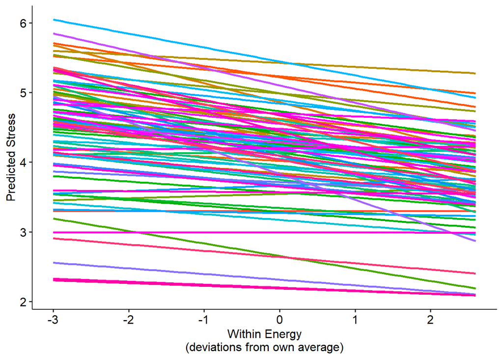

```r
visreg(m2, xvar = "Wenergy", by = "ID",
       breaks = unique(dm$ID),
       re.form = ~ (Wenergy | ID),
       partial = FALSE, rug = FALSE,
       gg = TRUE,
       xlab = "Within Energy\n(deviations from own average)",
       ylab = "Predicted Stress",
       overlay = TRUE) +
  theme_pubr() +
  theme(legend.position = "none")
```

What this figure helps show is how both the random intercept and slope influence the results and the individual differences in both level of stress and slope of stress on within person energy in the data. In this case, for example, it seems that the individual differences in level of stress may be larger than the individual differences in slope. With a few exceptions, a lot of the slopes are *relatively* similar, albeit not exactly the same.

# 3 You Try It

To try it out yourself, see if you can predict energy from between and within person stress including a random intercept and slope. Check diagnostics and try to solve any convergence or singularity issues you may run into (if you cannot solve them, try your best and detail what you tried). Make a conditional graph of your results.

Here are the basic steps.

1. Create a between and within person stress variable
2. Since we know `visreg()` does not like haven labeled type variables, check if any of your stress variables or the `dEnergy` variable is haven labeled and if so, convert them to numeric.
3. Fit a LMM using `lmer()` with both `Bstress` and `Wstress` as fixed effects and a random intercept and random `Wstress` slope by ID.
4. Check model diagnostics and where appropriate remove extreme values.
5. Make a summary of the final model.
6. Use `visreg()` to make a conditional plot.

```r
## 1. Create a between and within person stress variable

#### here's a start:
## dm[, meanDeviations() ]

## 2. Since we know `visreg()` does not like haven labeled type
##    variables, check if any of your stress variables or the `energy`
##    variable is haven labeled and if so, convert them to numeric.

#### here's a start:
## str(dm[, .(ID, dEnergy,       ) ])

## 3. Fit a LMM using `lmer()` with both `Bstress` and `Wstress` as fixed
##    effects and a random intercept and random `Wstress` slope by ID.

#### here's a start:
## yourmodel <- lmer(dEnergy ~          )

## 4. Check model diagnostics and where appropriate remove extreme
##    values.

#### here's a start:
## yourdiag <- modelDiagnostics(      )
## plot(  yourdiag  )


## 5. Make a summary of the final model.

#### here's a start
## summary(  yourmodel  )

## 6. Use `visreg()` to make a conditional plot.

#### here's a start, change up as needed
#### don't forget, if you drop some IDs, need to drop them here too
#### by changing the dataset in the unique() call
#visreg(m2, xvar = "Wmood", by = "ID",
#       breaks = unique(dm$ID),
#       re.form = ~ (Wmood | ID),
#       partial = FALSE, rug = FALSE,
#       gg = TRUE,
#       xlab = "Within Mood\n(deviations from own average)",
#       ylab = "Predicted Stress",
#       overlay = TRUE) +
#  theme_pubr() +
#  theme(legend.position = "none")
```

# 4 Summary

## 4.1 Conceptual

Key points to take away conceptually are:

- With multiple random effects, there are the standard deviations of each random effect but also the correlations (covariances) between random effects
- A simple understanding of a multivariate normal distribution
- We assume random effects follow a multivariate normal distribution
- How to use the Mahalanobis distance to evaluate multivariate outliers and whether data follow a multivariate normal distribution
- How to fit random slopes in mixed models
- How to interpret fixed and random slopes
- A general understanding of how to write up fixed and random slopes
- Strategies to resolve singularity and non convergence issues during model estimation
- The distinction between marginal and conditional graphs
- How to read and understand marginal and conditional graphs from LMMs

## 4.2 Code

| Function | What it does |
| --- | --- |
| `lmer()` | estimate a LMM |
| `confint()` | calculate confidence intervals for a LMM |
| `visreg()` | create marginal or conditional graphs from a LMM |
| `modelDiagnostics()` | evaluate model diagnostics for LMMs including of multivariate normality |
| `str()` | check the class / structure of data useful to find odd variable types |
| `lmerControl()` | way to change the algorithm used during model estimation and its options to help solve convergence issues |